# BIS 15L Practice Midterm 2

Jolane Abrams

## Load the libraries

```r
library(tidyverse)
library(janitor)
library(ggthemes)
options(scipen=999) #disables scientific notation when printing
```

```r
library(here)
```

## Gapminder

For this assignment, we are going to use data from [gapminder](https://www.gapminder.org/). Gapminder includes information about economics, population, social issues, and life expectancy from countries all over the world. We will use three data sets, so please load all three.

1. population_total.csv
2. income_per_person_gdppercapita_ppp_inflation_adjusted.csv
3. life_expectancy_years.csv

```r
population <- read_csv(here("practice_midterm2", "data", "population_total.csv")) %>%
  mutate(country=as_factor(country))
glimpse (population)
```

```
## Rows: 195
## Columns: 302
## $ country <fct> "Afghanistan", "Albania", "Algeria", "Andorra", "Angola", "Ant…
## $ `1800`  <dbl> 3280000, 400000, 2500000, 2650, 1570000, 37000, 534000, 413000…
## $ `1801`  <dbl> 3280000, 402000, 2510000, 2650, 1570000, 37000, 520000, 413000…
## $ `1802`  <dbl> 3280000, 404000, 2520000, 2650, 1570000, 37000, 506000, 413000…
## $ `1803`  <dbl> 3280000, 405000, 2530000, 2650, 1570000, 37000, 492000, 413000…
## $ `1804`  <dbl> 3280000, 407000, 2540000, 2650, 1570000, 37000, 479000, 413000…
## $ `1805`  <dbl> 3280000, 409000, 2550000, 2650, 1570000, 37000, 466000, 413000…
## $ `1806`  <dbl> 3280000, 411000, 2560000, 2650, 1570000, 37000, 453000, 413000…
## $ `1807`  <dbl> 3280000, 413000, 2560000, 2650, 1570000, 37000, 441000, 413000…
## $ `1808`  <dbl> 3280000, 414000, 2570000, 2650, 1570000, 37000, 429000, 413000…
## $ `1809`  <dbl> 3280000, 416000, 2580000, 2650, 1570000, 37000, 417000, 413000…
## $ `1810`  <dbl> 3280000, 418000, 2590000, 2650, 1570000, 37000, 420000, 413000…
## $ `1811`  <dbl> 3280000, 420000, 2600000, 2650, 1570000, 37000, 422000, 413000…
```

[output cut: 289 more lines]

```r
income <- read_csv(here("practice_midterm2", "data", "income_per_person_gdppercapita_ppp_inflation_adjusted.csv")) %>%
  mutate(country=as_factor(country))
glimpse(income)
```

```
## Rows: 193
## Columns: 242
## $ country <fct> "Afghanistan", "Albania", "Algeria", "Andorra", "Angola", "Ant…
## $ `1800`  <dbl> 603, 667, 715, 1200, 618, 757, 1640, 514, 817, 1850, 775, 1450…
## $ `1801`  <dbl> 603, 667, 716, 1200, 620, 757, 1640, 514, 822, 1850, 775, 1450…
## $ `1802`  <dbl> 603, 667, 717, 1200, 623, 757, 1650, 514, 826, 1860, 775, 1450…
## $ `1803`  <dbl> 603, 667, 718, 1200, 626, 757, 1650, 514, 831, 1870, 775, 1450…
## $ `1804`  <dbl> 603, 667, 719, 1210, 628, 757, 1660, 514, 836, 1880, 775, 1450…
## $ `1805`  <dbl> 603, 668, 720, 1210, 631, 757, 1660, 514, 841, 1880, 776, 1450…
## $ `1806`  <dbl> 603, 668, 721, 1210, 634, 757, 1670, 514, 845, 1890, 776, 1450…
## $ `1807`  <dbl> 603, 668, 722, 1210, 637, 758, 1680, 514, 850, 1900, 776, 1450…
## $ `1808`  <dbl> 603, 668, 723, 1220, 640, 758, 1680, 514, 855, 1910, 776, 1450…
## $ `1809`  <dbl> 603, 668, 724, 1220, 642, 758, 1690, 514, 860, 1920, 776, 1450…
## $ `1810`  <dbl> 604, 668, 725, 1220, 645, 758, 1690, 514, 865, 1920, 777, 1450…
## $ `1811`  <dbl> 604, 668, 726, 1220, 648, 758, 1700, 515, 869, 1940, 777, 1450…
```

[output cut: 229 more lines]

```r
life_expectancy <- read_csv(here("practice_midterm2", "data", "life_expectancy_years.csv")) %>%
  mutate(country=as_factor(country))
glimpse(life_expectancy)
```

```
## Rows: 187
## Columns: 302
## $ country <fct> "Afghanistan", "Albania", "Algeria", "Andorra", "Angola", "Ant…
## $ `1800`  <dbl> 28.2, 35.4, 28.8, NA, 27.0, 33.5, 33.2, 34.0, 34.0, 34.4, 29.2…
## $ `1801`  <dbl> 28.2, 35.4, 28.8, NA, 27.0, 33.5, 33.2, 34.0, 34.0, 34.4, 29.2…
## $ `1802`  <dbl> 28.2, 35.4, 28.8, NA, 27.0, 33.5, 33.2, 34.0, 34.0, 34.4, 29.2…
## $ `1803`  <dbl> 28.2, 35.4, 28.8, NA, 27.0, 33.5, 33.2, 34.0, 34.0, 34.4, 29.2…
## $ `1804`  <dbl> 28.2, 35.4, 28.8, NA, 27.0, 33.5, 33.2, 34.0, 34.0, 34.4, 29.2…
## $ `1805`  <dbl> 28.2, 35.4, 28.8, NA, 27.0, 33.5, 33.2, 34.0, 34.0, 34.4, 29.2…
## $ `1806`  <dbl> 28.1, 35.4, 28.8, NA, 27.0, 33.5, 33.2, 34.0, 34.0, 34.4, 29.2…
## $ `1807`  <dbl> 28.1, 35.4, 28.8, NA, 27.0, 33.5, 33.2, 34.0, 34.0, 34.4, 29.2…
## $ `1808`  <dbl> 28.1, 35.4, 28.8, NA, 27.0, 33.5, 33.2, 34.0, 34.0, 34.4, 29.2…
## $ `1809`  <dbl> 28.1, 35.4, 28.8, NA, 27.0, 33.5, 33.2, 34.0, 34.0, 34.4, 29.2…
## $ `1810`  <dbl> 28.1, 35.4, 28.8, NA, 27.0, 33.5, 33.2, 34.0, 34.0, 34.4, 29.2…
## $ `1811`  <dbl> 28.1, 35.4, 28.8, NA, 27.0, 33.5, 33.2, 34.0, 34.0, 34.4, 29.2…
```

[output cut: 289 more lines]

1. (3 points) Once you have an idea of the structure of the data, please make each data set tidy (hint: think back to pivots) and store them as new objects. You will need both the original (wide) and tidy (long) data!

```r
pop_long <- population %>%
  pivot_longer(cols = -country, names_to = "year", values_to = "population")
pop_long
```

```
## # A tibble: 58,695 × 3
##    country     year  population
##    <fct>       <chr>      <dbl>
##  1 Afghanistan 1800     3280000
##  2 Afghanistan 1801     3280000
##  3 Afghanistan 1802     3280000
##  4 Afghanistan 1803     3280000
##  5 Afghanistan 1804     3280000
##  6 Afghanistan 1805     3280000
##  7 Afghanistan 1806     3280000
##  8 Afghanistan 1807     3280000
##  9 Afghanistan 1808     3280000
## 10 Afghanistan 1809     3280000
## # … with 58,685 more rows
```

```r
inc_long <- income %>%
  pivot_longer(cols = -country, names_to = "year", values_to = "income")
inc_long
```

```
## # A tibble: 46,513 × 3
##    country     year  income
##    <fct>       <chr>  <dbl>
##  1 Afghanistan 1800     603
##  2 Afghanistan 1801     603
##  3 Afghanistan 1802     603
##  4 Afghanistan 1803     603
##  5 Afghanistan 1804     603
##  6 Afghanistan 1805     603
##  7 Afghanistan 1806     603
##  8 Afghanistan 1807     603
##  9 Afghanistan 1808     603
## 10 Afghanistan 1809     603
## # … with 46,503 more rows
```

```r
life_long <- life_expectancy %>%
  pivot_longer(cols = -country, names_to = "year", values_to = "life_expectancy")
life_long
```

```
## # A tibble: 56,287 × 3
##    country     year  life_expectancy
##    <fct>       <chr>           <dbl>
##  1 Afghanistan 1800             28.2
##  2 Afghanistan 1801             28.2
##  3 Afghanistan 1802             28.2
##  4 Afghanistan 1803             28.2
##  5 Afghanistan 1804             28.2
##  6 Afghanistan 1805             28.2
##  7 Afghanistan 1806             28.1
##  8 Afghanistan 1807             28.1
##  9 Afghanistan 1808             28.1
## 10 Afghanistan 1809             28.1
## # … with 56,277 more rows
```

2. (1 point) How many different countries are represented in the data? Provide the total number and their names. Since each data set includes different numbers of countries, you will need to do this for each one.

```r
inc_long %>% summarize(n_countries=n_distinct(country))
```

```
## # A tibble: 1 × 1
##   n_countries
##         <int>
## 1         193
```

```r
inc_long %>% count(country) %>% select(country)
```

```
## # A tibble: 193 × 1
##    country
##    <fct>
##  1 Afghanistan
##  2 Albania
##  3 Algeria
##  4 Andorra
##  5 Angola
##  6 Antigua and Barbuda
##  7 Argentina
##  8 Armenia
##  9 Australia
## 10 Austria
## # … with 183 more rows
```

```r
life_long%>% summarize(n_countries=n_distinct(country))
```

```
## # A tibble: 1 × 1
##   n_countries
##         <int>
## 1         187
```

```r
life_long %>% count(country) %>% select(country)
```

```
## # A tibble: 187 × 1
##    country
##    <fct>
##  1 Afghanistan
##  2 Albania
##  3 Algeria
##  4 Andorra
##  5 Angola
##  6 Antigua and Barbuda
##  7 Argentina
##  8 Armenia
##  9 Australia
## 10 Austria
## # … with 177 more rows
```

```r
pop_long%>% summarize(n_countries=n_distinct(country))
```

```
## # A tibble: 1 × 1
##   n_countries
##         <int>
## 1         195
```

```r
pop_long %>% count(country) %>% select(country)
```

```
## # A tibble: 195 × 1
##    country
##    <fct>
##  1 Afghanistan
##  2 Albania
##  3 Algeria
##  4 Andorra
##  5 Angola
##  6 Antigua and Barbuda
##  7 Argentina
##  8 Armenia
##  9 Australia
## 10 Austria
## # … with 185 more rows
```

## Life Expectancy

3. (2 points) Let’s limit the data to 100 years (1920-2020). For these years, which country has the highest average life expectancy? How about the lowest average life expectancy?

Highest

```r
life_long %>%
  filter(between(year, 1920, 2020)) %>%
  group_by(country) %>%
  summarize(mean_life_expectancy=mean(life_expectancy)) %>%
  arrange(desc(mean_life_expectancy))
```

```
## # A tibble: 187 × 2
##    country        mean_life_expectancy
##    <fct>                         <dbl>
##  1 Sweden                         73.5
##  2 Norway                         73.2
##  3 Netherlands                    73.0
##  4 Iceland                        72.9
##  5 Australia                      72.7
##  6 Switzerland                    72.7
##  7 Denmark                        71.9
##  8 Canada                         71.8
##  9 New Zealand                    71.4
## 10 United Kingdom                 71.1
## # … with 177 more rows
```

Lowest

```r
life_long %>%
  filter(between(year, 1920, 2020)) %>%
  group_by(country) %>%
  summarize(mean_life_expectancy=mean(life_expectancy)) %>%
  arrange(mean_life_expectancy)
```

```
## # A tibble: 187 × 2
##    country                  mean_life_expectancy
##    <fct>                                   <dbl>
##  1 Central African Republic                 41.8
##  2 Mali                                     41.8
##  3 Ethiopia                                 42.6
##  4 Sierra Leone                             42.6
##  5 Guinea-Bissau                            42.6
##  6 Burundi                                  42.8
##  7 Malawi                                   42.8
##  8 Uganda                                   43.3
##  9 Eritrea                                  43.4
## 10 Yemen                                    43.6
## # … with 177 more rows
```

4. (3 points) Although we can see which country has the highest life expectancy for the past 100 years, we don’t know which countries have changed the most. What are the top 5 countries that have experienced the biggest improvement in life expectancy between 1920-2020?

```r
life_long %>%
  select(country, year, life_expectancy) %>%
  filter(between(year, 1920, 2020)) %>%
  group_by(country) %>%
  mutate(improved = last(life_expectancy) - first(life_expectancy)) %>%
  ungroup() %>%
  select(country, improved) %>%
  arrange(-improved) %>%
  distinct(country, .keep_all = TRUE) %>%
  slice_head(n=5)
```

```
## # A tibble: 5 × 2
##   country         improved
##   <fct>              <dbl>
## 1 Kuwait              56.8
## 2 Kyrgyz Republic     56.5
## 3 Turkmenistan        55.3
## 4 South Korea         55
## 5 Tajikistan          54.3
```

5. (3 points) Make a plot that shows the change over the past 100 years for the country with the biggest improvement in life expectancy. Be sure to add appropriate aesthetics to make the plot clean and clear. Once you have made the plot, do a little internet searching and see if you can discover what historical event may have contributed to this remarkable change.

```r
kuwait <- life_long %>%
filter(country=="Kuwait") %>%
  filter(between(year, 1920, 2020)) %>%
  select(year, life_expectancy)%>%
  ggplot(aes(x=year, y=life_expectancy, group=1))+
  geom_line(color="green")
```

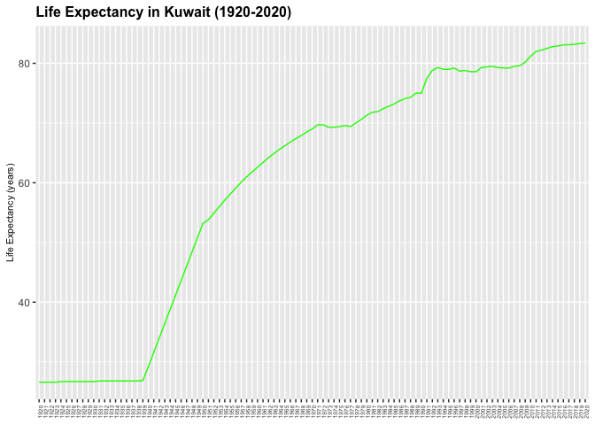

```r
kuwait+
  theme_gray()+
  theme(plot.title = element_text(size = 12, face = "bold"),
        axis.title = element_text(size = 8),
        axis.text.x = element_text(angle=85, hjust = 1, size=5)) +
  labs(title = "Life Expectancy in Kuwait (1920-2020)",
       x = NULL,
       y = "Life Expectancy (years)")
```

## Population Growth

6. (3 points) Which 5 countries have had the highest population growth over the past 100 years (1920-2020)?

```r
pop_long %>%
  filter(between(year, 1920, 2020)) %>%
  filter(year=="1920" | year=="2020") %>%
  pivot_wider(names_from = year,
              values_from = population) %>%
  mutate(growth =`2020`-`1920`) %>%
  top_n(5, growth) %>%
  arrange(-growth)
```

```
## # A tibble: 5 × 4
##   country          `1920`     `2020`     growth
##   <fct>             <dbl>      <dbl>      <dbl>
## 1 India         317000000 1380000000 1063000000
## 2 China         472000000 1440000000  968000000
## 3 Indonesia      47300000  274000000  226700000
## 4 United States 111000000  331000000  220000000
## 5 Pakistan       21700000  221000000  199300000
```

7. (4 points) Produce a plot that shows the 5 countries that have had the highest population growth over the past 100 years (1920-2020). Which countries appear to have had exponential growth?

[figure not shown]

```r
population %>%
  filter(country=="India" | country=="China" | country=="Pakistan" | country=="Indonesia" | country=="United States") %>%
  pivot_longer(-country,
               names_to = "year",
               values_to="population") %>%
  filter(year>=1920 & year<=2020) %>%
  ggplot(aes(x=year, y=population, group=country, color=country))+
  geom_line()+
  theme_linedraw()+
  theme(plot.title = element_text(size = 12, face = "bold"),
        axis.title = element_text(size = 10),
        axis.text.x = element_text(angle=75, hjust = 1, size=4)) +
  labs(title = "Population Growth in the 5 Highest-Growth Countries, 1920-2020",
       x = NULL,
       y = "Population (millions)")
```

## Income

The units used for income are gross domestic product per person adjusted for differences in purchasing power in international dollars.

8. (4 points) As in the previous questions, which countries have experienced the biggest growth in per person GDP. Show this as a table and then plot the changes for the top 5 countries. With a bit of research, you should be able to explain the dramatic downturns of the wealthiest economies that occurred during the 1980’s.

```r
inc_long %>%
  filter(between(year, 1920, 2020)) %>%
  filter(year=="1920" | year=="2020") %>%
  pivot_wider(names_from = year,
              values_from = income) %>%
  mutate(growth =`2020`-`1920`) %>%
  top_n(5, growth) %>%
  arrange(-growth)
```

```
## # A tibble: 5 × 4
##   country    `1920` `2020` growth
##   <fct>       <dbl>  <dbl>  <dbl>
## 1 Qatar        2300 116000 113700
## 2 Luxembourg   5730  95100  89370
## 3 Singapore    2440  90500  88060
## 4 Brunei       2130  75100  72970
## 5 Ireland      5170  74100  68930
```

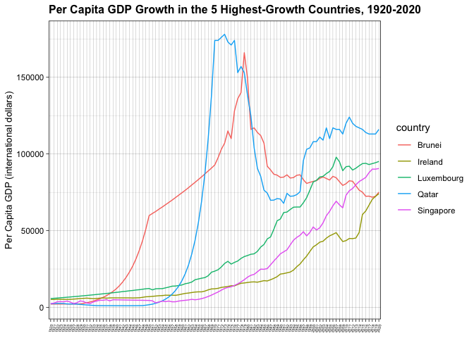

```r
income %>%
  filter(country=="Qatar" | country=="Luxembourg" | country=="Singapore" | country=="Brunei" | country=="Ireland") %>%
  pivot_longer(-country,
               names_to = "year",
               values_to="income") %>%
  filter(year>=1920 & year<=2020) %>%
  ggplot(aes(x=year, y=income, group=country, color=country))+
  geom_line()+
  theme_linedraw()+
  theme(plot.title = element_text(size = 12, face = "bold"),
        axis.title = element_text(size = 10),
        axis.text.x = element_text(angle=75, hjust = 1, size=4)) +
  labs(title = "Per Capita GDP Growth in the 5 Highest-Growth Countries, 1920-2020",
       x = NULL,
       y = "Per Capita GDP (international dollars)")
```

OPEC monopolized oil production in the 1970s, raising oil prices sky-high, which led to the massive GDP increases in Qatar and Brunei.

9. (3 points) Create three new objects that restrict each data set (life expectancy, population, income) to the years 1920-2020. Hint: I suggest doing this with the long form of your data. Once this is done, merge all three data sets using the code I provide below. You may need to adjust the code depending on how you have named your objects. I called mine `life_expectancy_100`, `population_100`, and `income_100`. For some of you, learning these `joins` will be important for your project.

```r
pop100 <- pop_long %>%
   filter(between(year, 1920, 2020))
pop100
```

```
## # A tibble: 19,695 × 3
##    country     year  population
##    <fct>       <chr>      <dbl>
##  1 Afghanistan 1920    10600000
##  2 Afghanistan 1921    10500000
##  3 Afghanistan 1922    10300000
##  4 Afghanistan 1923     9710000
##  5 Afghanistan 1924     9200000
##  6 Afghanistan 1925     8720000
##  7 Afghanistan 1926     8260000
##  8 Afghanistan 1927     7830000
##  9 Afghanistan 1928     7420000
## 10 Afghanistan 1929     7100000
## # … with 19,685 more rows
```

```r
inc100 <- inc_long %>%
  filter(between(year, 1920, 2020))
inc100
```

```
## # A tibble: 19,493 × 3
##    country     year  income
##    <fct>       <chr>  <dbl>
##  1 Afghanistan 1920    1490
##  2 Afghanistan 1921    1520
##  3 Afghanistan 1922    1550
##  4 Afghanistan 1923    1570
##  5 Afghanistan 1924    1600
##  6 Afghanistan 1925    1630
##  7 Afghanistan 1926    1650
##  8 Afghanistan 1927    1680
##  9 Afghanistan 1928    1710
## 10 Afghanistan 1929    1740
## # … with 19,483 more rows
```

```r
life100 <- life_long %>%
  filter(between(year, 1920, 2020))
life100
```

```
## # A tibble: 18,887 × 3
##    country     year  life_expectancy
##    <fct>       <chr>           <dbl>
##  1 Afghanistan 1920             30.6
##  2 Afghanistan 1921             30.7
##  3 Afghanistan 1922             30.8
##  4 Afghanistan 1923             30.8
##  5 Afghanistan 1924             30.9
##  6 Afghanistan 1925             31
##  7 Afghanistan 1926             31
##  8 Afghanistan 1927             31.1
##  9 Afghanistan 1928             31.1
## 10 Afghanistan 1929             31.2
## # … with 18,877 more rows
```

```r
gapminder_join <- inner_join(life100, pop100, by= c("country", "year"))
gapminder_join <- inner_join(gapminder_join, inc100, by= c("country", "year"))
gapminder_join
```

```
## # A tibble: 18,887 × 5
##    country     year  life_expectancy population income
##    <fct>       <chr>           <dbl>      <dbl>  <dbl>
##  1 Afghanistan 1920             30.6   10600000   1490
##  2 Afghanistan 1921             30.7   10500000   1520
##  3 Afghanistan 1922             30.8   10300000   1550
##  4 Afghanistan 1923             30.8    9710000   1570
##  5 Afghanistan 1924             30.9    9200000   1600
##  6 Afghanistan 1925             31      8720000   1630
##  7 Afghanistan 1926             31      8260000   1650
##  8 Afghanistan 1927             31.1    7830000   1680
##  9 Afghanistan 1928             31.1    7420000   1710
## 10 Afghanistan 1929             31.2    7100000   1740
## # … with 18,877 more rows
```

10. (4 points) Use the joined data to perform an analysis of your choice. The analysis should include a comparison between two or more of the variables `life_expectancy`, `population`, or `income.`

```r
gapminder_join %>%
  group_by(country) %>%
  summarize(mean_life_expectancy=mean(life_expectancy, na.rm=T),
            mean_income=mean(income, na.rm=T),
            mean_population=mean(population, na.rm=T))
```

```
## # A tibble: 187 × 4
##    country             mean_life_expectancy mean_income mean_population
##    <fct>                              <dbl>       <dbl>           <dbl>
##  1 Afghanistan                         43.8       1939.       14364950.
##  2 Albania                             61.4       4170.        2103921.
##  3 Algeria                             56.3       7850.       18523663.
##  4 Andorra                             79.8      22644.          33919.
##  5 Angola                              44.0       3964.       10088218.
##  6 Antigua and Barbuda                 63.2       9941.          58739.
##  7 Argentina                           65.8      11752.       25267327.
##  8 Armenia                             60.2       3403.        2258119.
##  9 Australia                           72.7      22795.       13247228.
## 10 Austria                             68.6      20916.        7453564.
## # … with 177 more rows
```

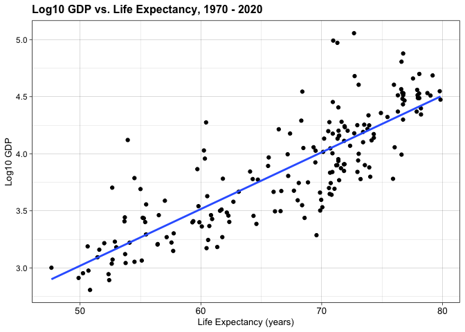

```r
gapminder_join %>%
  filter(between(year, 1970, 2020)) %>%
  group_by(country) %>%
  summarize(mean_life_expectancy=mean(life_expectancy, na.rm=T),
            mean_income=mean(income, na.rm=T)) %>%
  ggplot(aes(x=mean_life_expectancy, y=log10(mean_income)))+
  geom_point()+
  geom_smooth(method=lm, se=F)+
  theme_linedraw()+
  theme(plot.title = element_text(size = 12, face = "bold"),
        axis.title = element_text(size = 10),
        axis.text.x = element_text(size=10)) +
  labs(title = "Log10 GDP vs. Life Expectancy, 1970 - 2020",
       x = "Life Expectancy (years)",
       y = "Log10 GDP")
```